# Selección de modelos

# 1 Objetivo

Comparar diferentes modelos de regresión mediante criterios estadísticos que evalúan el ajuste, la parsimonia y la calidad predictiva.

# 2 Principales criterios de comparación

## 2.1 $R^2$: Coeficiente de determinación

$$R_p^2=1-\frac{\text {SSRes}_p}{\text {SSTotal}}$$

- Mide la proporción de variabilidad de $Y$ explicada por el modelo.
- Rango entre 0 y 1.
- Siempre aumenta al agregar más variables, aunque no sean relevantes.
- **No penaliza la complejidad**.

## 2.2 $R^2$ ajustado

- Penaliza la inclusión de variables irrelevantes.
- Permite comparar modelos con diferente número de predictores.
- Puede disminuir si se agregan variables innecesarias.
- Fórmula:
  $$R_{a, p}^2=1-\left(\frac{n-1}{n-p}\right) \frac{S S
  \operatorname{Res}_p}{S S T o t a l}$$

## 2.3 AIC: Akaike Information Criterion

$$A I C_p=n \ln \left(SSRes_p\right)-n \ln(n)+2 p$$

- Penaliza la complejidad del modelo.
- Se elige el modelo con menor $\textit{AIC}$.
- Útil cuando se prioriza la predicción.

## 2.4 BIC: Bayesian Information Criterion

$$BIC_p=n \ln \left(SSRes_p\right)-n \ln (n)+p \ln (n)$$

- Similar al $\textit{AIC}$, pero con penalización más fuerte.
- Más conservador.
- Útil cuando se prioriza parsimonia.

$\textit{Observación:}$ Tanto el $\textit{AIC}$ como el $\textit{BIC}$ representan un buen compromiso ($\textit{trade off}$) entre ajuste apropiado ($\textit{SSResp}$ pequeña) y parsimonia del modelo (pocos parámetros a ajustar, $p$ pequeño).

## 2.5 $C_p$ Mallows

$$C_p=\frac{{SSRes}_p}{MSRes_{\text{full}}}-(n-2
p)$$

donde

- $SSRes_p$ es la suma de los cuadrados de los errores del modelo con $p$ parámetros (es decir, con $p-1$ covariables).
- $MSRes_{\text{full}}$ es el estimador de la varianza del error $\sigma^2$, calculado bajo el modelo con todas las posibles covariables.
- Un modelo adecuado tiene $C_p \approx p$.
- Requiere un modelo “completo” correcto: Depende de que $MSRes_{\text{full}}$ sea una buena estimación del error real.

## 2.6 ¿Cuál de estos criterios utilizar?

- Todos miden cualidades deseables en un modelo de regresión:
  - Balance entre ajuste y complejidad (evitar sobreajuste/subajuste).
  - Capacidad predictiva.
- Escenario ideal (poco común)
  - Un único modelo puede optimizar todos los criterios simultáneamente ($\textit{AIC}$, $\textit{BIC}$, $C_p$, $R^2$, $R^2_a$).
  - Si ocurre, es el modelo claramente elegible.
- Situación típica
  - Diferentes criterios pueden seleccionar distintos modelos como “óptimos”.

    $\textit{AIC}$ podría favorecer un modelo con más predictores.

    $\textit{BIC}$ podría elegir uno más parsimonioso.
- Estrategia recomendada
  - Paso 1: Usar los criterios para filtrar un conjunto pequeño de modelos candidatos.
  - Paso 2: Evaluar la capacidad predictiva de estos modelos (cross validation, bootstraping).
  - Paso 3: Analizar en profundidad estos modelos, considerando:
    - Objetivos del estudio (predicción vs. explicación).
    - Conocimiento del área (relevancia teórica de las variables).

  Paso 4: Validar los supuestos (normalidad, homocedasticidad, multicolinealidad).
- Conclusión
  - No hay un criterio único “mejor”. La selección debe ser:
    - Integral: Combinar métricas.
    - Transparente: Documentar el proceso de decisión.

# 3 Métodos de selección automática de modelos

## 3.1 Todos los subconjuntos posibles (Best subset)

- Ajustan todos los submodelos posibles (es decir, $2^k$ combinaciones).
- Luego, los clasifican según algún criterio de bondad de ajuste ($\textit{AIC}$, $\textit{BIC}$, etc.).
- Ventaja principal:
  - Es el único método que garantiza encontrar el modelo que optimiza el criterio elegido, porque analiza todas las combinaciones posibles.
- Desventaja principal:
  - Limitación computacional: requiere ajustar $2^k$ regresiones.
  - Si $k>40$ es más de un billón de modelos.
- Alternativas para casos con muchas variables: se usan métodos secuenciales (computacionalmente factibles).

## 3.2 Métodos secuenciales

Son técnicas de selección de variables en modelos de regresión que agregan o eliminan predictores de forma secuencial, de acuerdo a algún criterio, evitando el costo computacional de evaluar todos los subconjuntos posibles.

### 3.2.1 Stepwise Forward (Selección hacia Adelante)

Comienza con un modelo sin variables y, en cada paso, agrega la variable que más contribuye según el criterio predefinido (mayor reducción en $RSS$, mayor $R^2_a$, menor $\textit{AIC}$, menor $\textit{BIC}$, etc.)

- Pasos del algoritmo:
  - Inicio: Modelo vacío (solo intercept).
  - Selección: En cada iteración, se prueba agregar cada variable no incluida y se elige la que aporta una mejora mayor. Por ejemplo: menor $\textit{AIC}$.
  - Para: cuando ningún cambio mejora el criterio elegido.
- Ventajas:
  - Eficiente con un gran número de variables.
  - Útil cuando hay más predictores que observaciones ($k>n$).
- Desventajas:
  - No es recomendable en presencia de multicolinealidad.
  - Se recomienda analizar multicoliniealidad antes.

### 3.2.2 Stepwise Backward (Eliminación hacia Atrás)

Comienza con un modelo que incluye todas las variables y, en cada paso, elimina la variable que más contribuye según el criterio predefinido (mayor reducción en $RSS$, mayor $R^2_a$, menor $\textit{AIC}$, menor $\textit{BIC}$, etc.)

- Pasos del algoritmo:
  - Inicio: comienza con un modelo con todas las variables.
  - Eliminación: En cada iteración, se remueve la variable con menor contribución de acuerdo al criterio elegido.
  - Para: cuando ningún cambio mejora el criterio elegido.
- Ventajas:
  - Considera todas las variables desde el inicio, captando posibles interacciones.
  - Más robusto que forward cuando $k<n$.
- Desventajas:
  - Costo computacional alto si $K$ es grande.
  - No es recomendable en presencia de multicolinealidad.

### 3.2.3 Stepwise Bidireccional (Stepwise Mixto o “Híbrido”)

Combina $\textit{forward}$ y $\textit{backward}$. En cada paso, agrega la mejor variable pero también revisa si alguna incluida puede eliminarse.

- Pasos del algoritmo:
  - Inicio: Modelo vacío o con un subconjunto inicial.
  - Adición/Eliminación:
    - Primero, agrega la variable más significativa (como en forward).
    - Luego, verifica si alguna variable incluida dejó de ser relevante (como en backward) y la remueve si es necesario.
  - Para: cuando ningún cambio mejora el criterio elegido.
- Ventajas:
  - Más flexible que forward o backward por sí solos.
  - Reduce el riesgo de omitir variables importantes o incluir irrelevantes.
- Desventajas:
  - Mayor costo computacional que los métodos unidireccionales.

## 3.3 ¿Cuándo Usar Stepwise?

- Una cantidad $k$ moderada de variables (ej. 20-100).
- Cuando best subset es inviable por costo computacional.
- Alternativas:
  - Regularización (Lasso/Ridge/Elastic Net): Más eficientes y menos propensas a overfitting.
  - Métodos basados en árboles (Random Forest): Para selección no lineal.

$\textit{Observación:}$ Estos métodos siempre hay que validarlos con técnicas de validación cruzada para estudiar la tendencia al overfitting.

- ¿Qué es el overfitting o sobreajuste?
  - Ocurre cuando un modelo estadístico o de machine learning se ajusta demasiado bien a los datos de entrenamiento, incluyendo su ruido y variaciones aleatorias, en lugar de capturar solo los patrones generales.
  - Pero no funcionan bien en datos nuevos.
  - El modelo tiene muy bajo error en los datos de entrenamiento, pero tiene error alto en datos de validación/prueba.
  - Por ejemplo: en regresión, el $R^2$ es casi 1 en entrenamiento, pero cercano a 0 en prueba.
- Notas Clave
  - $\textit{BIC}$ tiende a seleccionar modelos más simples que $\textit{AIC}$ (penaliza más los parámetros).
  - Forward/Backward pueden dar resultados distintos si hay correlación entre variables.
  - El mejor modelo es el que minimiza el error en test (no necesariamente el que tiene más/menos variables).

# 4 Ejemplos

## 4.1 Función $\textit{stepAIC}$

- Paquete: $\textit{MASS}$.
- Cargar previamente la librería $\textit{MASS}$.

## 4.2 Función $regsubset$

- Paquete: leaps
- Cargar previamente la librería $\textit{leaps}$

## 4.3 🧪 Ejemplo práctico en R

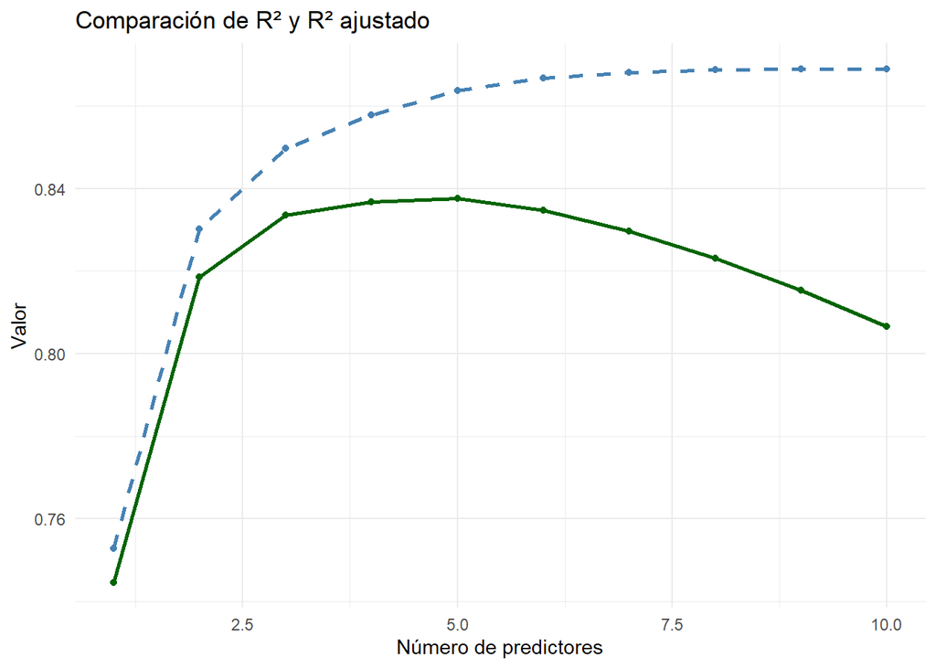

```r
library(leaps)

data(mtcars)

# Selección de subconjuntos usando regresión exhaustiva
reg <- regsubsets(mpg ~ ., data = mtcars, nvmax = 10)
reg_summary <- summary(reg)

# Extraemos criterios
rsq <- reg_summary$rsq
adjr2 <- reg_summary$adjr2
bic <- reg_summary$bic

df <- data.frame(
  NumVars = 1:length(rsq),
  R2 = rsq,
  AdjR2 = adjr2,
  BIC = bic
)

# Gráfico de R2 y R2 ajustado
ggplot(df, aes(x = NumVars)) +
  geom_line(aes(y = R2), color = "steelblue", size = 1, linetype = "dashed") +
  geom_line(aes(y = AdjR2), color = "darkgreen", size = 1) +
  geom_point(aes(y = R2), color = "steelblue") +
  geom_point(aes(y = AdjR2), color = "darkgreen") +
  labs(
    title = "Comparación de R² y R² ajustado",
    x = "Número de predictores",
    y = "Valor"
  ) +
  theme_minimal()
```

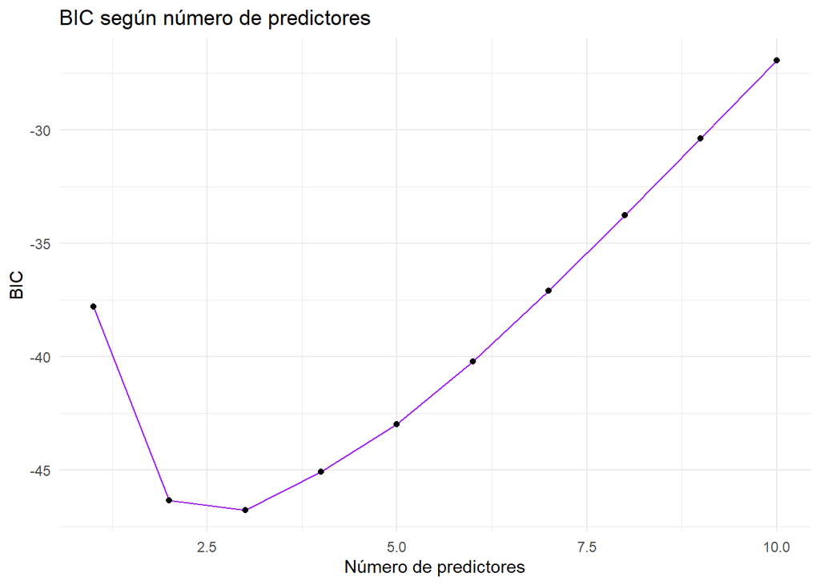

```r
# Gráfico de BIC
ggplot(df, aes(x = NumVars, y = BIC)) +
  geom_line(color = "purple") +
  geom_point() +
  labs(
    title = "BIC según número de predictores",
    x = "Número de predictores",
    y = "BIC"
  ) +
  theme_minimal()
```